# Lecture 03: Visualizing Data

January 27 2020

### Learning objectives for today:

Visualizing your data:

1. Making lovely plots using `ggplot` in R
- Visualization of categorical data: use `ggplot`’s `geom_bar()`
- Visualization of continuous data: use `ggplot`’s `geom_histogram()`
2. Describe distributions based on shape, centre, spread

### Visualization of categorical data

- What is the best way to visualize one categorical variable at a time?

### Visualization of categorical data

- Generally speaking, **it is not a good idea to use pie charts**

### Visualziation of categorical data

Can you judge the area of the slices?

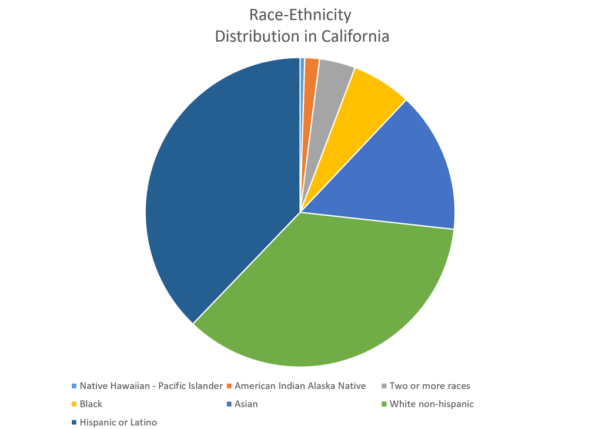

### Visualziation of categorical data

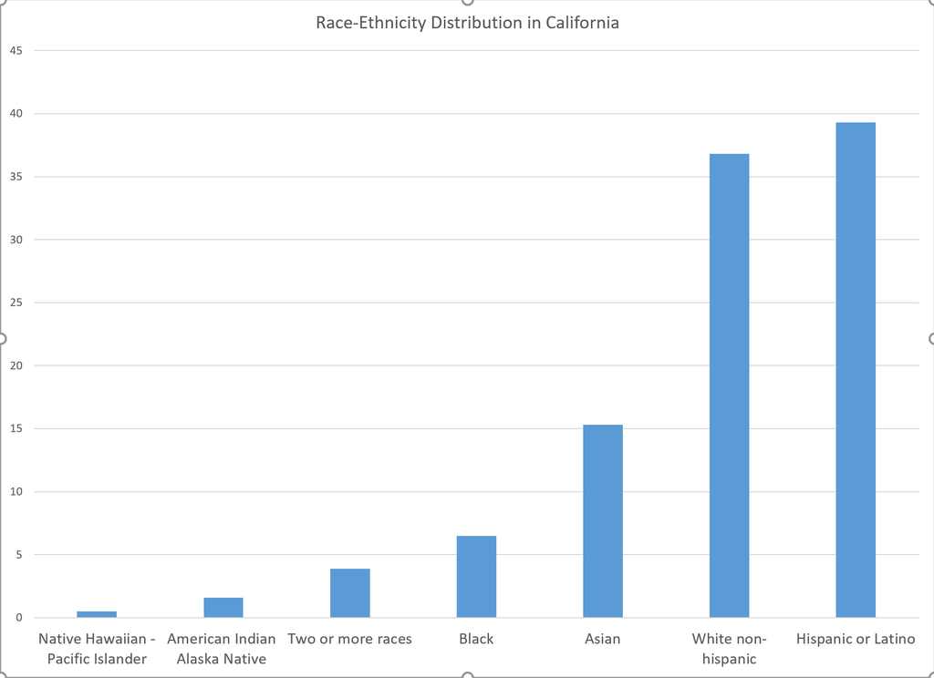

### Visualization of categorical data

- We prefer **bar graphs** (also called **bar charts**) for the display of categorical data.
- Bar charts display the number or percent of data for each level of the categorical variable being plotted

### Example: infectious disease data

- Task: Make a bar chart of the percent of cases on infectious disease for each category of disease.
- First, read and view the infectious disease data from Baldi and Moore:

```r
id_data <- read_csv("Ch01_ID-data.csv")
```

### Example: infectious disease data

```r
id_data
```

```
## # A tibble: 7 x 4
##   disease            type      number_cases percent_cases
##   <chr>              <chr>            <dbl>         <dbl>
## 1 Chlamydia          STI             174557         66.4
## 2 Gonorrhea          STI              44974         17.1
## 3 Pertussis          Pertussis        11219          4.27
## 4 Campylobacteriosis Foodborne         7919          3.01
## 5 Early syphilis     STI               7191          2.74
## 6 Salmonellosis      Foodborne         5361          2.04
## 7 Other              Other            11559          4.40
```

### Example: infectious disease data

- Note the variables `number_cases` and `percent_cases`
- What do you want the bar chart to display? What is the x and y variables for a bar chart?

## Introducing ggplot

### First step to building a `ggplot()`: set up the canvas

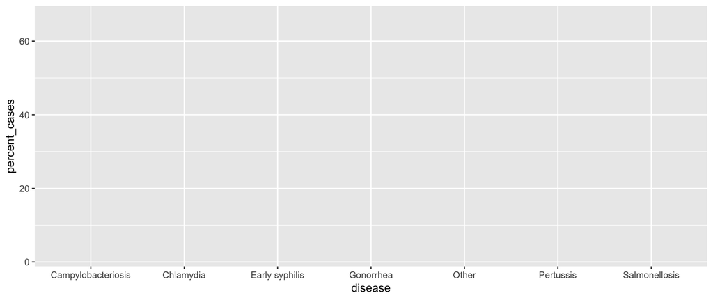

### Next choose a function

- We will use a `geom_` function to create our chart

`ggplot()`’s `geom_bar()` makes a bar chart

### Syntax for bar charts

ggplot(id_data, aes(x = disease, y = percent_cases)) +

geom_bar(stat = “identity”)

stat = “identity” tells geom_bar that we supplied a y variable that is exactly what we want to plot.

We do not need geom_bar() to calculate the number or percent for us.

### `ggplot()`’s `geom_bar()` makes a bar chart

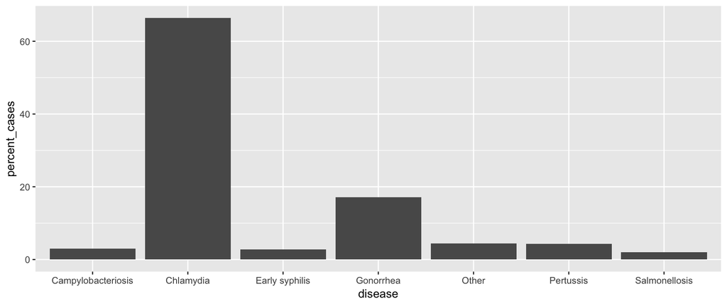

### some additions to ggplot for style

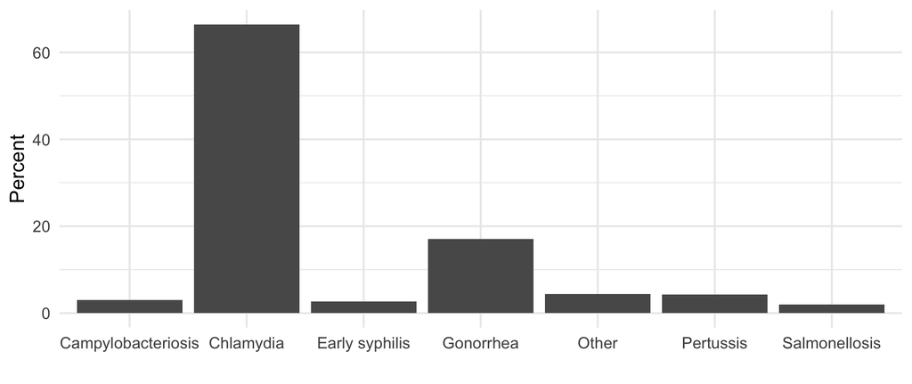

base_size controls the font size on these plots

theme_minimal affects the “look” of the plot it removes the grey background and adds grey gridlines

### `fct_reorder` reorders `disease` according to value of `percent_cases`

```r
id_data <- id_data %>%
  mutate(disease_ordered = fct_reorder(disease, percent_cases, .desc = T))
```

### Re-ordered plot

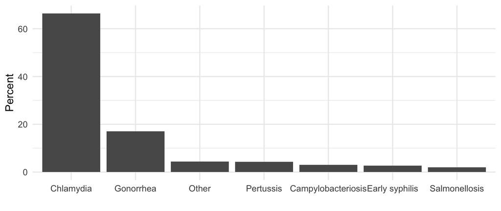

### Use `aes(fill = type)` to link the bar’s fill to the disease type

geom_bar(stat = “identity”, aes(fill = type)) +

theme(legend.position = “top”)

### Use `aes(fill = type)` to link the bar’s fill to the disease type

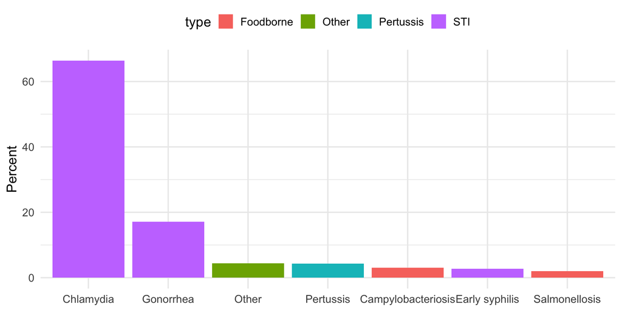

## Visualizing quantitative variables

### Visualize quantitative variables using histograms

- Histograms look a lot like bar charts, except that the bars touch because the underlying scale is continuous and the order of the bars matters
- In order to make a histogram, the underlying data needs to be **binned** into categories and the number or percent of data in each category becomes the height of each bar.
- the **bins** devide the entire range of data into a series of intervals and counts the number of observations in each interval
- the intervals must be consecutive and non-overlapping and are almost always chosen to be of equal size

### Example: opioid state prescription rates

Problem: To determine the extent to which opioid prescribing rates vary across US congressional districts.

Plan: In an observational cross-sectional framework using secondary data, they constructed 2016 congressional district–level opioid prescribing rate estimates using a population-weighted methodology.

Data: In the data structure we have State as the unit of analysis, and measured perscription rates as the variable of interest

### Example: opioid state prescription rates

```r
opi_data <- read.csv("Ch01_opioid-data.csv")
head(opi_data)
```

```
##   Rank State   Mean Median    SD    Min    Max Num_Districts
## 1    1    AL 121.31 113.09 21.87 105.58 166.69             7
## 2    2    AR 115.22 115.13  8.59 104.80 125.79             4
## 3    3    TN 108.12 108.26 19.16  73.60 133.00             9
## 4    4    MS 105.64 106.25 17.36  83.90 126.14             4
## 5    5    LA  98.38  98.88 10.34  83.22 112.65             6
## 6    6    KY  98.13  85.76 26.72  77.62 147.00             6
```

- `Mean` provides the mean prescribing rate per 100 individuals. Thus, a mean of 121.31 implies that in Alabama, there were 121.31 opioid prescriptions per 100 persons, an average across the 7 congressional districts.

### Histogram of opioid prescription rates

- Task: Make a histogram of the average prescribing rates across US states
- What is the x variable? What is the y variable?
- What `geom` should be used?

### Histogram of opioid prescription rates - default is 30 bins

ggplot(data = opi_data, aes(x = Mean)) +

geom_histogram(col = “white”) +

labs(x = “Mean opioid prescription rate (per 100 individuals)”,

```
   y = "Number of states") +
```

theme_minimal(base_size = 15)

### Histogram of opioid prescription rates

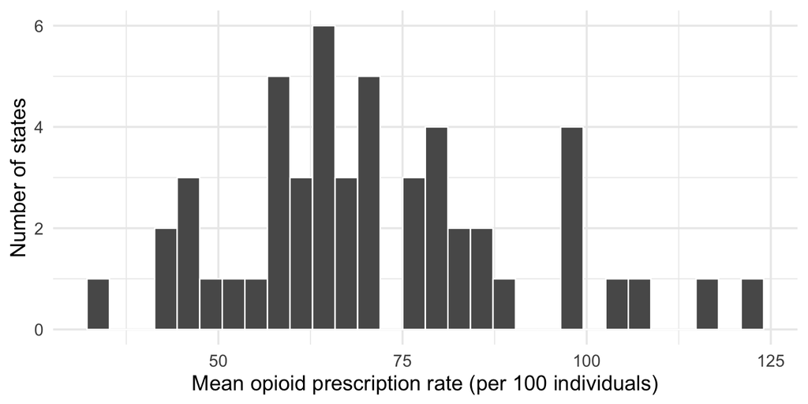

### same graph, change the bins `geom_histogram(binwidth = 5)`

ggplot(data = opi_data, aes(x = Mean)) +

geom_histogram(col = “white”, binwidth = 5) +

labs(x = “Mean opioid prescription rate (per 100 individuals)”,

```
   y = "Number of states") +
```

theme_minimal(base_size = 15)

### same graph, change the bins `geom_histogram(binwidth = 5)`

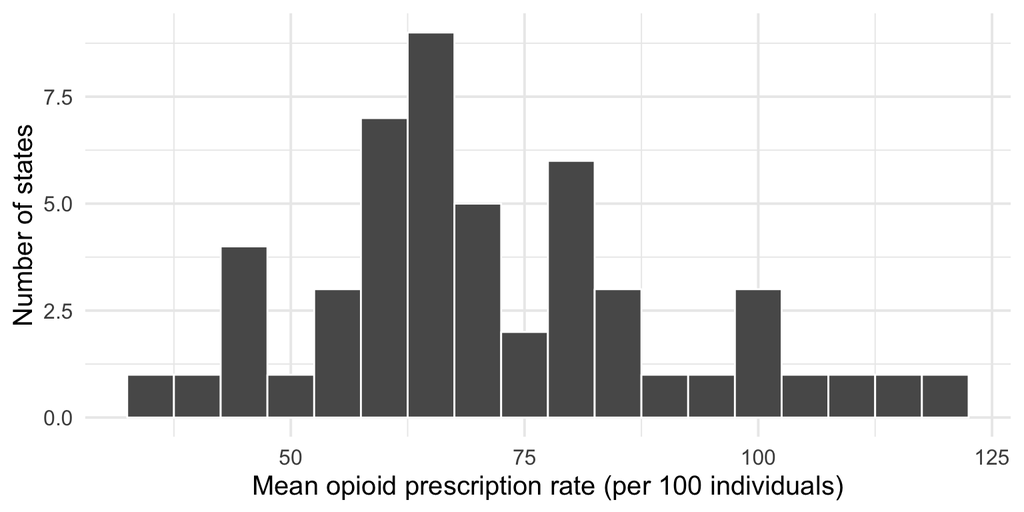

### change the bins again `geom_histogram(binwidth = 10)`

ggplot(data = opi_data, aes(x = Mean)) +

geom_histogram(col = “white”, binwidth = 10) +

labs(x = “Mean opioid prescription rate (per 100 individuals)”,

```
   y = "Number of states") +
```

theme_minimal(base_size = 15)

### change the bins again `geom_histogram(binwidth = 10)`

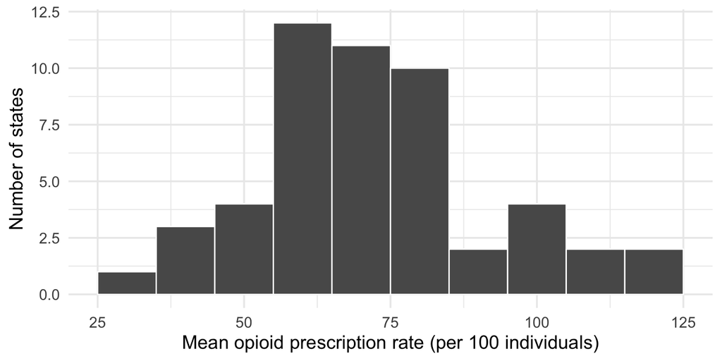

## Describing your distribution based on shape, center and spread

### Shape, Center, Spread

- When we examine histograms, we can make comments on a distribution’s:
  - **Shape**: Is the distribution **symmetric** or **skewed** to the left or right?
  - **Center**: Does the histogram have one peak (unimodal), or two (bimodal) or more?
  - **Spread**: How spread out are the values? What is the range of the data?
  - **Outliers**: Do any of the measurements fall outside of the range of most of the data points?

### Is this skewed left or skewed right?

[figure not shown]

### Center - one hump or two?

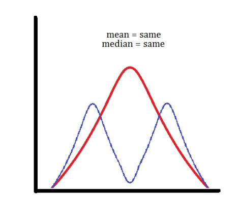

### Outlier

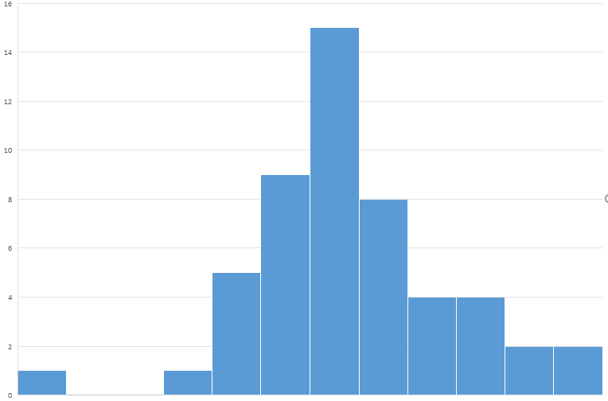

## Participation

### Participation

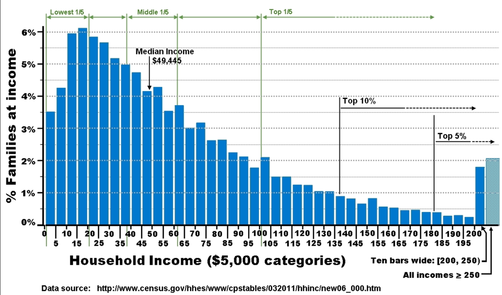

## Time plots

### Visualize quantitative variables over time using time plots

- **Time plots** are a specific subset of line plots where the x variable is time.
- Unlike the previous plots, the time plot shows a relationship between two variables:
  1. a quantitative variable
  2. time
- Often times, these plots can be used to look for cycles (e.g., seasonal patterns that recur each year) or trends (e.g., overall increases or decreases seen over time).

### Time plot

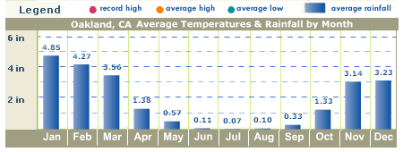

### Life expectancy for White men in California

Make a scatter plot of the life expectancy for White men in California over time.

Since the dataset contains 39 states across two genders and two races, first use a function to subset the data to contain only White men in California.

Which function from last lecture do we need?

- `mutate()`, `select()`, `filter()`, `rename()`, or `arrange()`?

### `dplyr`’s `filter()` to select a subset of rows

```r
wm_cali <- le_data %>% filter(state == "California",
                              sex == "Male",
                              race == "white")

#this is equivalent:
wm_cali <- le_data %>% filter(state == "California" & sex == "Male" & race == "white")
```

### Here we use `geom_point` to make a graph with dots

ggplot(data = wm_cali, aes(x = year, y = LE)) +

geom_point() +

labs(title = “Life expectancy in white men in California, 1969-2013”,

```
   y = "Life expectancy",

   x = "Year",

   caption = "Data from Riddell et al. (2018)")
```

### Here we use `geom_point` to make a graph with dots

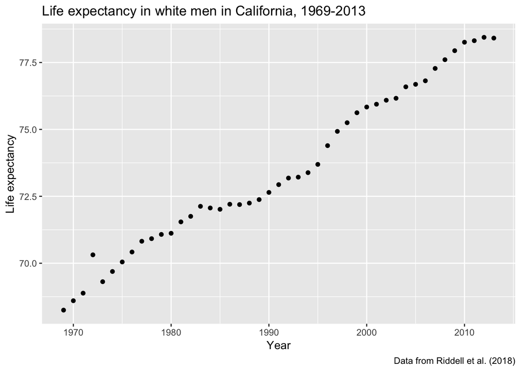

### `geom_line()` to make a line plot

ggplot(data = wm_cali, aes(x = year, y = LE)) +

geom_line(col = “blue”) +

labs(title = “Life expectancy in white males in California, 1969-2013”,

```
   y = "Life expectancy",

   x = "Year",

   caption = "Data from Riddell et al. (2018)")
```

### `geom_line()` to make a line plot

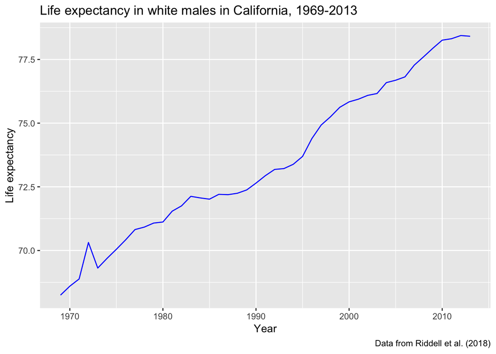

### R Recap: new code?

1. ‘ggplot’ to set up a canvas for graphics
2. `geom_bar(stat = "identity")` to make a bar chart when you specify the y variable
3. `geom_histogram()` to make a histogram for which ggplot needs to calculate the count
4. `fct_reorder(var1, var2)` to reorder a categorical variable (`var1`) by a numeric variable (`var2`)
   - from the `forcats` package
5. `geom_point()` to make a plot with dots
6. `geom_line()` to make a plot with lines

### How to get help with code

- Ask questions during labs, GSI office hours, or on Piazza discussion forum. Use the appropriate thread!
- Develop your online search skills. For example if you have a `ggplot2` question, begin your google search with “r ggplot” and then describe your issues, e.g., “r ggplot how do I make separate lines by a second variable”.
- The most common links that will appear are:
  - https://stackoverflow.com: Crowd-sourced answers that have been upvoted. The top answer is often the best one.
  - https://ggplot2.tidyverse.org/: The official ggplot2 webpage is very helpful.
  - https://community.rstudio.com/: The RStudio community page.
  - https://rpubs.com/: Web pages made by R users that often contain helpful tutorials.

### We only skimmed the surface!

- Here is some extra material for those of you who love data visualization. This material won’t be tested.
  - [RStudio ggplot2 cheatsheet](https://www.rstudio.com/wp-content/uploads/2015/03/ggplot2-cheatsheet.pdf)
  - [Kieran Healy’s data visualization book](https://www.amazon.com/gp/product/0691181624/ref=as_li_tl?ie=UTF8&tag=kieranhealysw-20&camp=1789&creative=9325&linkCode=as2&creativeASIN=0691181624&linkId=16d53b3cc1ec3bc3aac60b27c29b92e8)

### Parting Humor

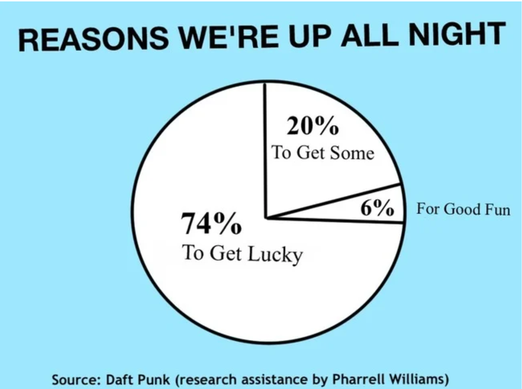